# Analysis example

DRL

11/23/2020

This is an example RMarkdown script demonstrating some *very* basic manipulation, visualization, and analysis of microbiome data stored as a phyloseq object. For more details on working with phyloseq objects, look at the phylose [tutorial pages](https://joey711.github.io/phyloseq/tutorials-index.html). This [microbiome workflow](https://bioconductor.org/help/course-materials/2017/BioC2017/Day1/Workshops/Microbiome/MicrobiomeWorkflowII.html) in R / Bioconductor tutorial is also worth checking out.

```r
# Load packages
library(tidyverse)
library(magrittr)
library(phyloseq)
library(vegan)

### Custom functions ###
#remove empty OTUs
sweepOTUs <- function(phy.in){
  phy.in %>% prune_taxa(taxa_sums(.)>0, .)
}
#convert to relative abundance
proportional <- function(phy.in){
  phy.in %>% transform_sample_counts(function(x){x*min(sample_sums(.))/sum(x)})
}

# Import phyloseq object
(phy <- readRDS("output/processing/compiled/phy.rds"))
```

```
## phyloseq-class experiment-level object
## otu_table()   OTU Table:         [ 456 taxa and 84 samples ]
## sample_data() Sample Data:       [ 84 samples by 6 sample variables ]
## tax_table()   Taxonomy Table:    [ 456 taxa by 7 taxonomic ranks ]
## refseq()      DNAStringSet:      [ 456 reference sequences ]
```

## Quality control

### Negative controls

```r
# Extract negative control samples (in this case samples with NA in the Samp_site column of the meta data)
(negs <- phy %>% subset_samples(is.na(Samp_site)) %>% sweepOTUs)
```

```
## phyloseq-class experiment-level object
## otu_table()   OTU Table:         [ 4 taxa and 6 samples ]
## sample_data() Sample Data:       [ 6 samples by 6 sample variables ]
## tax_table()   Taxonomy Table:    [ 4 taxa by 7 taxonomic ranks ]
## refseq()      DNAStringSet:      [ 4 reference sequences ]
```

```r
# There are only 4 taxa present in the negative controls with only a couple of reads each
taxa_sums(negs)
```

```
##   OTU.1  OTU.11 OTU.412 OTU.431
##       4       5       4       3
```

```r
# OTU.1 and OTU.11 are likely cross talk
# OTU.412 and OTU.431 are only in the negative controls
taxa_sums(phy)[taxa_names(negs)]
```

```
##   OTU.1  OTU.11 OTU.412 OTU.431
##  152248    6385       4       3
```

```r
# We can safely just remove the negative controls
phy %<>% subset_samples(!is.na(Samp_site)) %>% sweepOTUs
```

### Sequencing depth

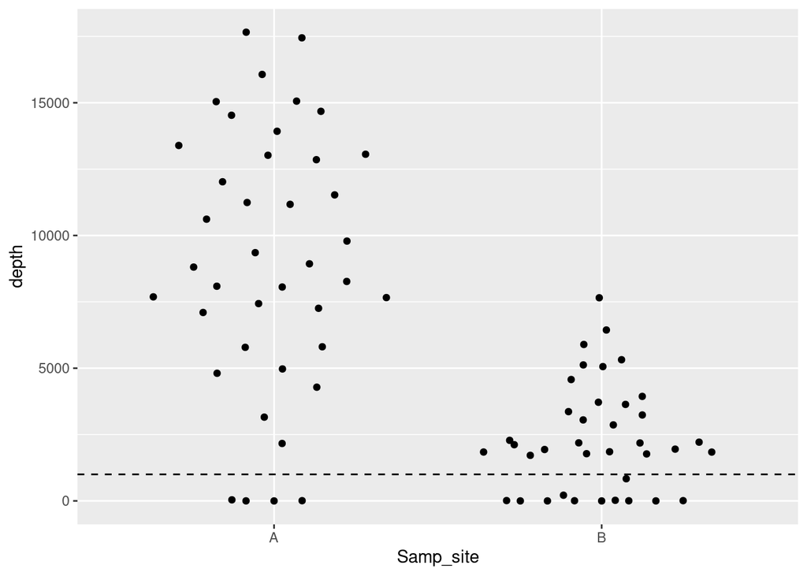

```r
# Plot sequencing depth for each site
sample_data(phy) %>% data.frame %>%
  mutate(depth=sample_sums(phy)) %>%
  ggplot(aes(x=Samp_site, y=depth)) +
    ggbeeswarm::geom_quasirandom() +
    geom_hline(yintercept = 1000, linetype = "dashed")
```

Samples from site B did not sequence as well as samples form site A. This could be due to taxon bias, sample quality, or something else. This is not necessarily a problem, but should be kept in mind when interpreting differences between sites. Based on the plot, we will remove samples with < 1000 read from our analyses.

```r
(phy %<>% prune_samples(sample_sums(.)>1000, .))
```

```
## phyloseq-class experiment-level object
## otu_table()   OTU Table:         [ 454 taxa and 63 samples ]
## sample_data() Sample Data:       [ 63 samples by 6 sample variables ]
## tax_table()   Taxonomy Table:    [ 454 taxa by 7 taxonomic ranks ]
## refseq()      DNAStringSet:      [ 454 reference sequences ]
```

### OTU prevelance

```r
phy %>% filter_taxa(., function(x) {sum(x>0) > 0.02*nsamples(.)}, TRUE)
```

```
## phyloseq-class experiment-level object
## otu_table()   OTU Table:         [ 269 taxa and 63 samples ]
## sample_data() Sample Data:       [ 63 samples by 6 sample variables ]
## tax_table()   Taxonomy Table:    [ 269 taxa by 7 taxonomic ranks ]
## refseq()      DNAStringSet:      [ 269 reference sequences ]
```

## Analysis

### Ordination

Visualize difference in community composition between sites using NMDS

```r
# Fit an NMDS ordination using Bray-Curtis dissimilarity of proportional abundance
phy.ord <- phy %>% proportional %>% ordinate("NMDS","bray")
```

```
## Square root transformation
## Wisconsin double standardization
## *** Solution reached
```

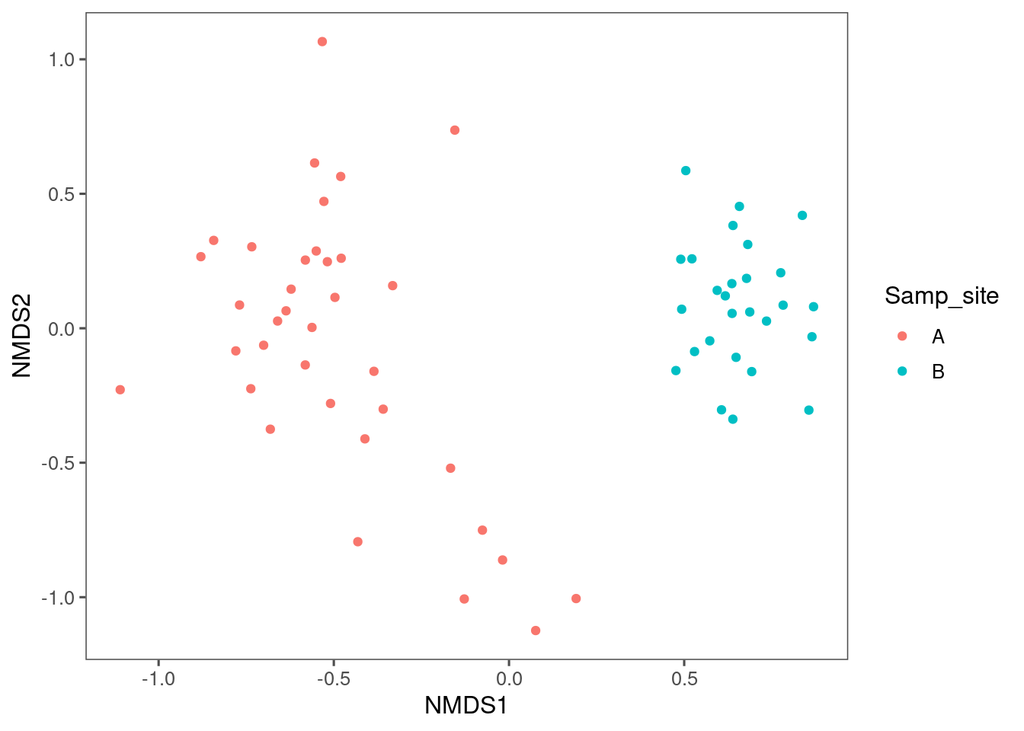

```r
plot.ord <- plot_ordination(phy,phy.ord,color="Samp_site") + ggthemes::theme_few()
# Save image to file
ggsave("output/figs/NMDS.pdf", plot.ord)
plot.ord
```

### PerMANOVA

Test the magnitude of the difference in community composition between sites

```r
phy.dist <- phy %>% proportional %>% phyloseq::distance("bray")
adonis(phy.dist~sample_data(phy)$Samp_site)
```

```
##
## Call:
## adonis(formula = phy.dist ~ sample_data(phy)$Samp_site)
##
## Permutation: free
## Number of permutations: 999
##
## Terms added sequentially (first to last)
##
##                            Df SumsOfSqs MeanSqs F.Model      R2 Pr(>F)
## sample_data(phy)$Samp_site  1    3.7235  3.7235   43.93 0.41866  0.001 ***
## Residuals                  61    5.1703  0.0848         0.58134
## Total                      62    8.8938                 1.00000
## ---
## Signif. codes:  0 '***' 0.001 '**' 0.01 '*' 0.05 '.' 0.1 ' ' 1
```

Since the spread of the samples appeared to vary in the NMDS ordination, we can check betadispersion too.

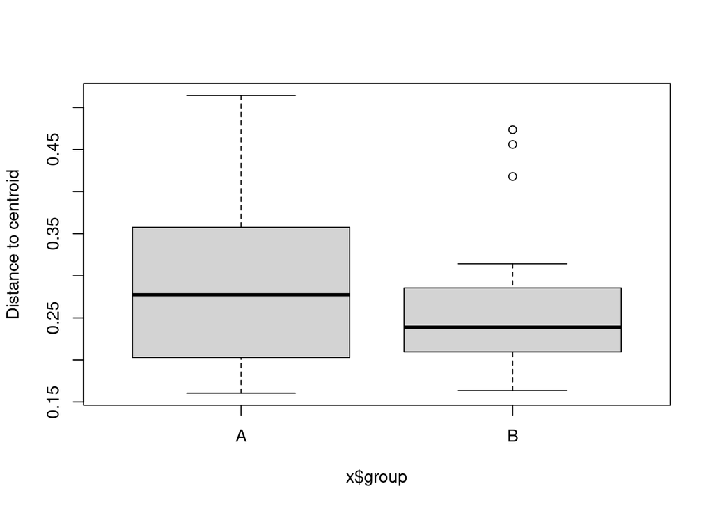

```r
phy.beta <- betadisper(phy.dist, sample_data(phy)$Samp_site)
boxplot(phy.beta)
```

```r
permutest(phy.beta)
```

```
##
## Permutation test for homogeneity of multivariate dispersions
## Permutation: free
## Number of permutations: 999
##
## Response: Distances
##           Df  Sum Sq   Mean Sq      F N.Perm Pr(>F)
## Groups     1 0.00963 0.0096275 1.2505    999  0.276
## Residuals 61 0.46963 0.0076989
```